# Differential expression analysis

Learning objectives:

- Perform expletory analysis on gene-level count matrix using PCA & Heatmap
- Perform differential expression in DESeq2
- Perform gene annotation to add gene names
- Perform pathway analysis which provides functional annotation as well as information about gene products that interact with each other in a given pathway

# 1- Background

This tutorial shows an example of RNA-seq data analysis with DESeq2. Using data from GSE37704, with processed data available as attachment. This dataset has six samples from GSE37704.

https://www.ncbi.nlm.nih.gov/geo/query/acc.cgi?acc=GSE37704

# 2- Install and load libraries

```r
# BiocManager::install("DESeq2")
# install.packages("pheatmap")
# install.packages("ggplot2")
#
# BiocManager::install("AnnotationDbi")
# BiocManager::install("org.Hs.eg.db")
# BiocManager::install("pathview")
# BiocManager::install("gage")
# BiocManager::install("gageData")
```

# 3- Reading and preprocess data

## 3.1- Import data

First, import the countdata and metadata

```r
setwd("C:\\Personal\\BMEG310 2023\\BMEG310_2022\\Diff expression")
# Import metadata
colData = read.csv("GSE37704_metadata.csv", row.names=1)
colData
```

```
##               condition
## SRR493366 control_sirna
## SRR493367 control_sirna
## SRR493368 control_sirna
## SRR493369      hoxa1_kd
## SRR493370      hoxa1_kd
## SRR493371      hoxa1_kd
```

```r
# import as dataframe
countData = read.csv("GSE37704_featurecounts.csv",row.names=1)
# convert dataframe to matrix
countData = as.matrix(countData)
```

## 3.2- Preprocess data

### ALWAYS keep in mind to preprocess the data!

1. Here we see that column **length** is not a sample (Experiment), so we need to remove it

```r
countData = countData[,-1]
```

2. Filter data where you only have 0 or 1 read count across all samples.

```r
countData <- countData[rowSums(countData)>1,]
```

Now, let see some top data

```r
head(countData)
```

```
##                 SRR493366 SRR493367 SRR493368 SRR493369 SRR493370 SRR493371
## ENSG00000279457        23        28        29        29        28        46
## ENSG00000187634       124       123       205       207       212       258
## ENSG00000188976      1637      1831      2383      1226      1326      1504
## ENSG00000187961       120       153       180       236       255       357
## ENSG00000187583        24        48        65        44        48        64
## ENSG00000187642         4         9        16        14        16        16
```

# 4- Exploratory analysis and visualization

## 4.1- Sample distances

A useful first step in an RNA-seq analysis is often to assess overall similarity between samples: Which samples are similar to each other, which are different? Does this fit to the expectation from the experiment’s design?

We use the R function dist to calculate the Euclidean distance between samples. We need to transpose the matrix of values using **t**, because the **dist** function expects the different samples to be rows of its argument, and different dimensions (here, genes) to be columns.

```r
sampleDists = dist(t(countData),upper = TRUE)
sampleDists
```

```
##           SRR493366 SRR493367 SRR493368 SRR493369 SRR493370 SRR493371
## SRR493366            66873.12 270664.54 289761.98 342550.89 448329.82
## SRR493367  66873.12           210318.38 290032.82 324873.19 425776.67
## SRR493368 270664.54 210318.38           354547.37 318904.57 392801.26
## SRR493369 289761.98 290032.82 354547.37           113625.23 196701.34
## SRR493370 342550.89 324873.19 318904.57 113625.23           121971.74
## SRR493371 448329.82 425776.67 392801.26 196701.34 121971.74
```

We visualize the distances in a *heatmap* in a figure below, using the function pheatmap from the **pheatmap** package.

In order to plot the sample distance matrix with the rows/columns arranged by the distances in our distance matrix, we manually provide sampleDists to the clustering_distance argument of the pheatmap function. Otherwise the pheatmap function would assume that the matrix contains the data values themselves, and would calculate distances between the rows/columns of the distance matrix, which is not desired.

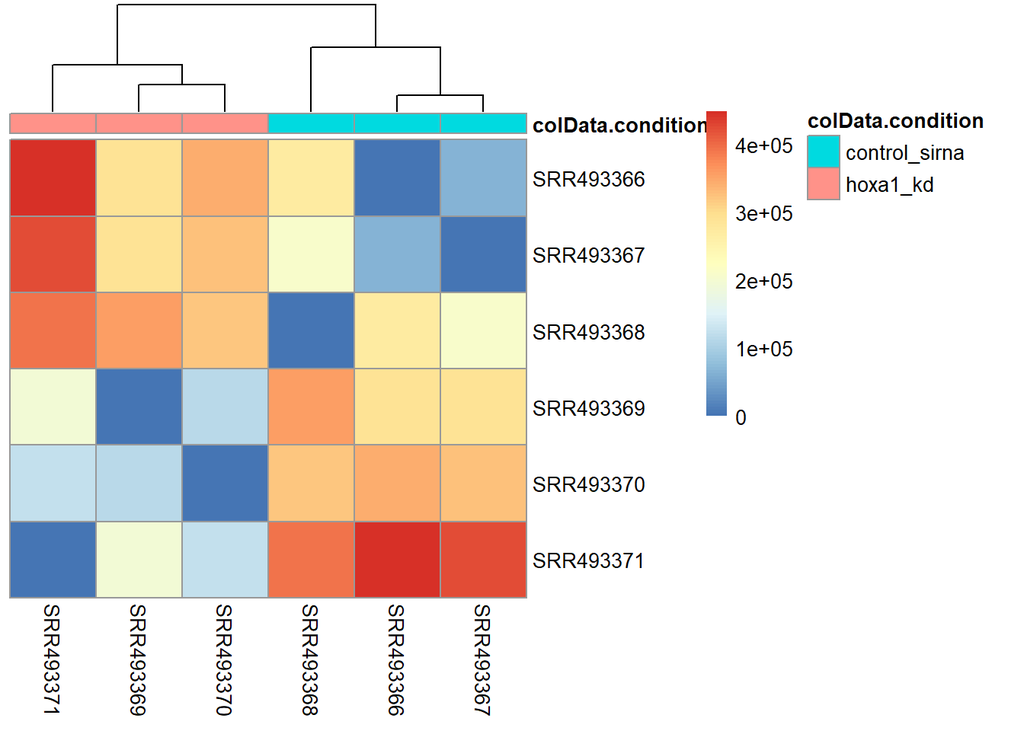

```r
annot_col = data.frame(colData$condition)
row.names(annot_col) <- rownames(colData)

sampleDistMatrix = as.matrix( sampleDists )
rownames(sampleDistMatrix) = colnames(countData)
colnames(sampleDistMatrix) = colnames(countData)

pheatmap(sampleDistMatrix,
         clustering_distance_rows = sampleDists,
         clustering_distance_cols = sampleDists,
         cluster_rows=FALSE, show_rownames=TRUE,
         cluster_cols=TRUE,
         annotation_col=annot_col)
```

## 4.2- PCA plot

Another way to visualize sample-to-sample distances is a principal components analysis (PCA). In this ordination method, the data points (here, the samples) are projected onto the 2D plane such that they spread out in the two directions that explain most of the differences (figure below). The x-axis is the direction that separates the data points the most. The values of the samples in this direction are written PC1. The y-axis is a direction (it must be orthogonal to the first direction) that separates the data the second most.

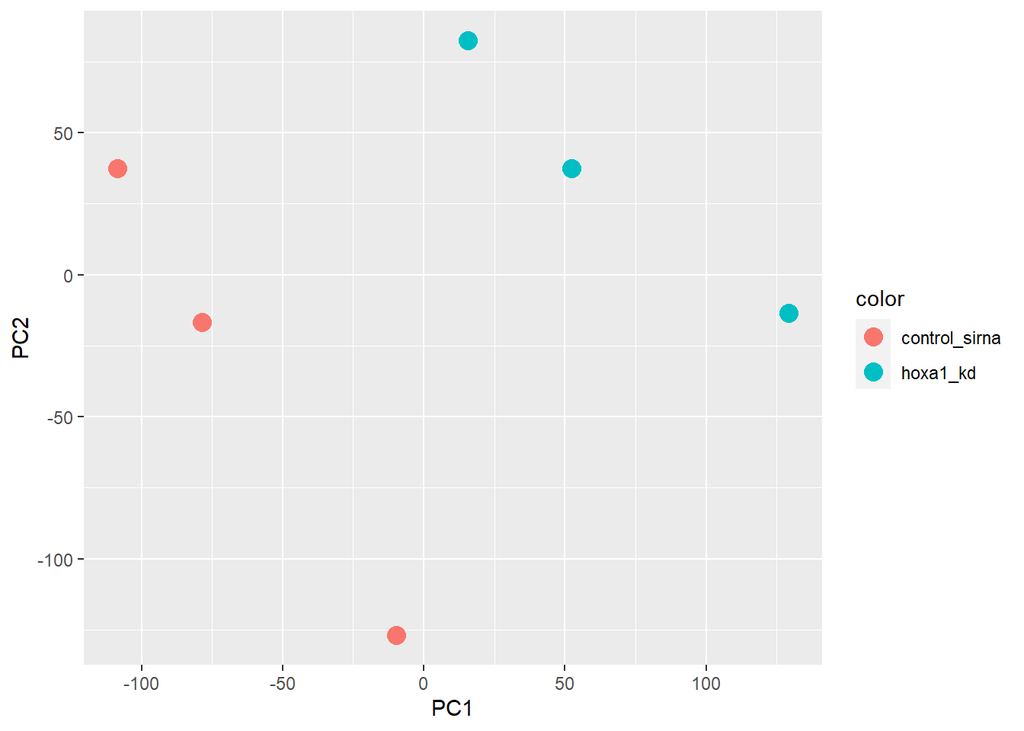

```r
pca_res <- prcomp(t(countData), scale. = TRUE)
score <- pca_res$x

score = as.data.frame(score)
score$color <- as.factor(colData$condition)


ggplot(score, aes(x=PC1, y=PC2,  color=color)) +
  geom_point(size = 4)
```

```r
colnames(countData)
```

```
## [1] "SRR493366" "SRR493367" "SRR493368" "SRR493369" "SRR493370" "SRR493371"
```

```r
library("gridExtra")
```

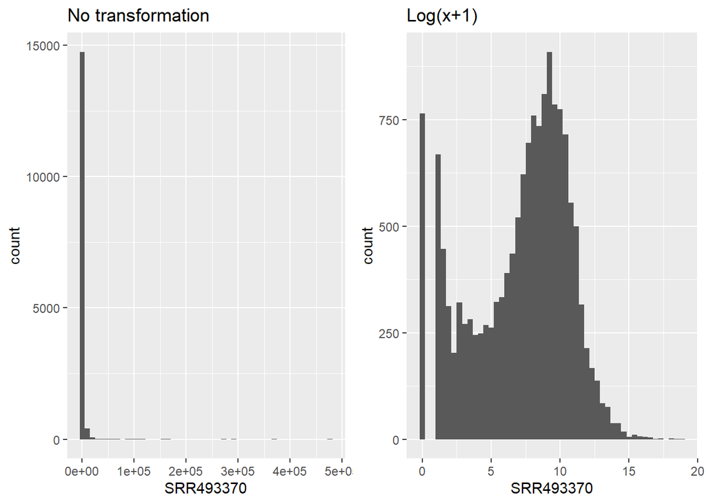

```r
p1 <- ggplot(as.data.frame(countData),aes(x=SRR493370))+
  geom_histogram(bins=50)+
  labs(title="No transformation")

log2 <- log(countData+1, base = 2)
p2 <- ggplot(as.data.frame(log2),aes(x=SRR493370))+
  geom_histogram(bins=50)+
  labs(title="Log(x+1)")

grid.arrange(p1, p2, ncol = 2)
```

# 5- Set up the DESeqDataSet Object and run the DESeq pipeline

Differential expression analysis with DESeq2 involves multiple steps as displayed in the flowchart below. Briefly,

- DESeq2 will model the raw counts, using normalization factors (size factors) to account for differences in library depth.
- Then, it will estimate the gene-wise dispersions and shrink these estimates to generate more accurate estimates of dispersion to model the counts.
- Finally, DESeq2 will fit the negative binomial model and perform hypothesis testing using the Wald test or Likelihood Ratio Test.

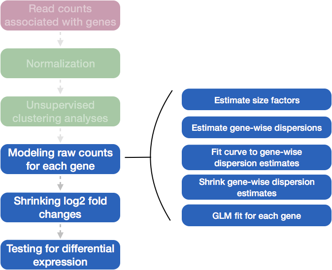

img

We’re now ready to use `DESeq2`, the package that will perform differential expression.

```r
dds = DESeqDataSetFromMatrix(countData=countData,
                              colData=colData,
                              design=~condition)
```

## Running the differential expression pipeline

```r
dds = DESeq(dds)
dds
```

```
## class: DESeqDataSet
## dim: 15280 6
## metadata(1): version
## assays(4): counts mu H cooks
## rownames(15280): ENSG00000279457 ENSG00000187634 ... ENSG00000276345
##   ENSG00000271254
## rowData names(22): baseMean baseVar ... deviance maxCooks
## colnames(6): SRR493366 SRR493367 ... SRR493370 SRR493371
## colData names(2): condition sizeFactor
```

This function will print out a message for the various steps it performs. These are described in more detail in the manual page for DESeq, which can be accessed by typing ?DESeq. Briefly these are: the estimation of size factors (controlling for differences in the sequencing depth of the samples), the estimation of dispersion values for each gene, and fitting a generalized linear model.

## Building the results table

Calling results without any arguments will extract the estimated log2 fold changes and p values for the last variable in the design formula. If there are more than 2 levels for this variable, results will extract the results table for a comparison of the last level over the first level.

```r
res <- results(dds)
res
```

```
## log2 fold change (MLE): condition hoxa1 kd vs control sirna
## Wald test p-value: condition hoxa1 kd vs control sirna
## DataFrame with 15280 rows and 6 columns
##                  baseMean log2FoldChange     lfcSE       stat      pvalue
##                 <numeric>      <numeric> <numeric>  <numeric>   <numeric>
## ENSG00000279457   29.9136      0.1792571 0.3248216   0.551863 5.81042e-01
## ENSG00000187634  183.2296      0.4264571 0.1402658   3.040350 2.36304e-03
## ENSG00000188976 1651.1881     -0.6927205 0.0548465 -12.630158 1.43990e-36
## ENSG00000187961  209.6379      0.7297556 0.1318599   5.534326 3.12428e-08
## ENSG00000187583   47.2551      0.0405765 0.2718928   0.149237 8.81366e-01
## ...                   ...            ...       ...        ...         ...
## ENSG00000273748  35.30265       0.674387  0.303666   2.220817 2.63633e-02
## ENSG00000278817   2.42302      -0.388988  1.130394  -0.344117 7.30758e-01
## ENSG00000278384   1.10180       0.332991  1.660261   0.200565 8.41039e-01
## ENSG00000276345  73.64496      -0.356181  0.207716  -1.714752 8.63908e-02
## ENSG00000271254 181.59590      -0.609667  0.141320  -4.314071 1.60276e-05
##                        padj
##                   <numeric>
## ENSG00000279457 6.85033e-01
## ENSG00000187634 5.14039e-03
## ENSG00000188976 1.75974e-35
## ENSG00000187961 1.13044e-07
## ENSG00000187583 9.19159e-01
## ...                     ...
## ENSG00000273748 0.047753083
## ENSG00000278817 0.808837549
## ENSG00000278384 0.892832531
## ENSG00000276345 0.139306314
## ENSG00000271254 0.000045217
```

We could have equivalently produced this results table with the following more specific command.

```r
res = results(dds, contrast=c("condition", "hoxa1_kd", "control_sirna"))
```

As res is a DataFrame object, it carries metadata with information on the meaning of the columns:

```r
mcols(res, use.names = TRUE)
```

```
## DataFrame with 6 rows and 2 columns
##                        type            description
##                 <character>            <character>
## baseMean       intermediate mean of normalized c..
## log2FoldChange      results log2 fold change (ML..
## lfcSE               results standard error: cond..
## stat                results Wald statistic: cond..
## pvalue              results Wald test p-value: c..
## padj                results   BH adjusted p-values
```

| baseMean | giving means across all samples |
| --- | --- |
| log2FoldChange | log2 fold changes of gene expression from one condition to another. Reflects how different the expression of a gene in one condition is from the expression of the same gene in another condition. |
| lfcSE | standard errors (used to calculate p value) |
| stat | test statistics used to calculate p value) |
| pvalue | p-values for the log fold change |
| padj | adjusted p-values |

Of course, this estimate has an uncertainty associated with it, which is available in the column **lfcSE**, the standard error estimate for the log2 fold change estimate. We can also express the uncertainty of a particular effect size estimate as the result of a statistical test. The purpose of a test for differential expression is to test whether the data provides sufficient evidence to conclude that this value is really different from zero. DESeq2 performs for each gene a hypothesis test to see whether evidence is sufficient to decide against the null hypothesis that there is zero effect of the treatment on the gene and that the observed difference between treatment and control was merely caused by experimental variability (i.e., the type of variability that you can expect between different samples in the same treatment group). As usual in statistics, the result of this test is reported as a p value, and it is found in the column **pvalue**. Remember that a p value indicates the probability that a fold change as strong as the observed one, or even stronger, would be seen under the situation described by the null hypothesis.

We can also summarize the results with the following line of code, which reports some additional information, that will be covered in later sections.

```r
summary(res)
```

```
##
## out of 15280 with nonzero total read count
## adjusted p-value < 0.1
## LFC > 0 (up)       : 4351, 28%
## LFC < 0 (down)     : 4399, 29%
## outliers [1]       : 0, 0%
## low counts [2]     : 590, 3.9%
## (mean count < 1)
## [1] see 'cooksCutoff' argument of ?results
## [2] see 'independentFiltering' argument of ?results
```

Note that there are many genes with differential expression due to treatment at the FDR level of 10%.

However, there are two ways to be more strict about which set of genes are considered significant:

- lower the false discovery rate threshold (the threshold on padj in the results table)
- raise the log2 fold change threshold from 0 using the lfcThreshold argument of results

If we lower the false discovery rate threshold, we should also inform the results() function about it, so that the function can use this threshold for the optimal independent filtering that it performs:

```r
res.05 <- results(dds, alpha = 0.05)
table(res.05$padj < 0.05)
```

```
##
## FALSE  TRUE
##  5910  8185
```

Sometimes a subset of the *p* values in `res` will be `NA` (“not available”). This is *DESeq*’s way of reporting that all counts for this gene were zero, and hence not test was applied. In addition, *p* values can be assigned `NA` if the gene was excluded from analysis because it contained an extreme count outlier.

If we want to raise the log2 fold change threshold, so that we test for genes that show more substantial changes due to treatment, we simply supply a value on the log2 scale. For example, by specifying lfcThreshold = 1, we test for genes that show significant effects of treatment on gene counts more than doubling or less than halving, because 2^1=2.

```r
resLFC1 <- results(dds, lfcThreshold=1)
table(resLFC1$padj < 0.1)
```

```
##
## FALSE  TRUE
## 13012  1083
```

## p-values and adjusted p-values

We can order our results table by the smallest p value:

```r
res.order <- res[order(res$pvalue),]
summary(res.order)
```

```
##
## out of 15280 with nonzero total read count
## adjusted p-value < 0.1
## LFC > 0 (up)       : 4351, 28%
## LFC < 0 (down)     : 4399, 29%
## outliers [1]       : 0, 0%
## low counts [2]     : 590, 3.9%
## (mean count < 1)
## [1] see 'cooksCutoff' argument of ?results
## [2] see 'independentFiltering' argument of ?results
```

How many adjusted p-values were less than 0.1?

```r
sum(res.order$padj < 0.1, na.rm=TRUE)
```

```
## [1] 8750
```

## Multiple testing

Novices in high-throughput biology often assume that thresholding these *p* values at a low value, say 0.05, as is often done in other settings, would be appropriate – but it is not. We briefly explain why:

There are 8594 genes with a *p* value below 0.05 among the 15280 genes, for which the test succeeded in reporting a *p* value:

```r
sum(res$pvalue < 0.05, na.rm=TRUE)
```

```
## [1] 8594
```

```r
sum(!is.na(res$pvalue))
```

```
## [1] 15280
```

*DESeq2* uses the Benjamini-Hochberg (BH) adjustment as described in the base R *p.adjust* function; in brief, this method calculates for each gene an adjusted *p* value which answers the following question: if one called significant all genes with a *p* value less than or equal to this gene’s *p* value threshold, what would be the fraction of false positives (the *false discovery rate*, FDR) among them (in the sense of the calculation outlined above)? These values, called the BH-adjusted *p* values, are given in the column `padj` of the `res` object.

Hence, if we consider a fraction of 6% false positives acceptable, we can consider all genes with an adjusted *p* value below 6% = 0.06 as significant. How many such genes are there?

```r
sum(res$padj < 0.06, na.rm=TRUE)
```

```
## [1] 8295
```

We subset the results table to these genes and then sort it by the log2 fold change estimate to get the significant genes with the strongest down-regulation.

```r
resSig <- subset(res, padj < 0.06)
head(resSig[ order( resSig$log2FoldChange ), ])
```

```
## log2 fold change (MLE): condition hoxa1_kd vs control_sirna
## Wald test p-value: condition hoxa1 kd vs control sirna
## DataFrame with 6 rows and 6 columns
##                  baseMean log2FoldChange     lfcSE      stat      pvalue
##                 <numeric>      <numeric> <numeric> <numeric>   <numeric>
## ENSG00000171587   2.56166       -4.90288   1.51501  -3.23621 0.001211271
## ENSG00000155011   7.97124       -4.60137   1.14805  -4.00799 0.000061238
## ENSG00000101306   1.88837       -4.42604   1.64500  -2.69060 0.007132349
## ENSG00000179855   3.76040       -4.42484   1.40111  -3.15809 0.001588053
## ENSG00000188581   1.79503       -4.40515   1.63867  -2.68824 0.007182999
## ENSG00000164342   3.51766       -4.32310   1.41632  -3.05235 0.002270591
##                        padj
##                   <numeric>
## ENSG00000171587 0.002743805
## ENSG00000155011 0.000162263
## ENSG00000101306 0.014358533
## ENSG00000179855 0.003531410
## ENSG00000188581 0.014448617
## ENSG00000164342 0.004948810
```

…and with the strongest upregulation. The *order* function gives the indices in increasing order, so a simple way to ask for decreasing order you can use the argument `decreasing=TRUE`.

```r
head(resSig[ order( resSig$log2FoldChange, decreasing=TRUE), ])
```

```
## log2 fold change (MLE): condition hoxa1_kd vs control_sirna
## Wald test p-value: condition hoxa1 kd vs control sirna
## DataFrame with 6 rows and 6 columns
##                  baseMean log2FoldChange     lfcSE      stat       pvalue
##                 <numeric>      <numeric> <numeric> <numeric>    <numeric>
## ENSG00000128052  158.2495        8.82209  1.034742   8.52588  1.51649e-17
## ENSG00000141668   43.9416        8.82063  1.204102   7.32548  2.38039e-13
## ENSG00000004799   97.2602        8.11744  1.037421   7.82464  5.09106e-15
## ENSG00000109321 3907.1905        7.47917  0.288068  25.96324 1.28883e-148
## ENSG00000162892   25.2789        7.05210  1.221093   5.77523  7.68468e-09
## ENSG00000073756 1357.6271        6.33775  0.339984  18.64130  1.48596e-77
##                         padj
##                    <numeric>
## ENSG00000128052  9.35235e-17
## ENSG00000141668  1.19794e-12
## ENSG00000004799  2.78954e-14
## ENSG00000109321 1.14745e-146
## ENSG00000162892  2.91324e-08
## ENSG00000073756  4.40986e-76
```

## Plot counts

It can also be useful to examine the counts of reads for a single gene across the groups. A simple function for making this plot is plotCounts, which normalizes counts by sequencing depth and adds a pseudocount of 1/2 to allow for log scale plotting. The counts are grouped by the variables in intgroup, where more than one variable can be specified. Here we specify the gene which had the smallest p value from the results table created above. You can select the gene to plot by rowname or by numeric index.

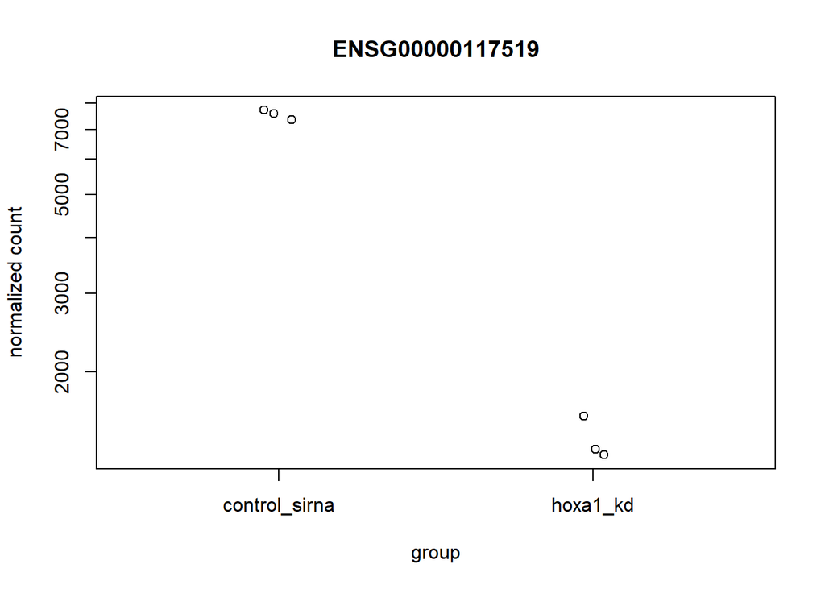

```r
plotCounts(dds, gene=which.min(res$padj), intgroup="condition")
```

## Volcano plot

A volcano plot is a type of scatter plot that represents the differential expression of features (e.g., genes). In this plot, the log-transformed adjusted p-values are displayed on the y-axis, while the log2 fold change values are plotted on the x-axis. The code in the chunk below includes two functions: one for preparing the data for the volcano plot and another for plotting the volcano plot.

```r
library(ggplot2)
library(ggrepel)

# Function 1: Prepare DESeq2 results for plotting
prepare_res_for_plot <- function(res) {
  # Convert DESeqResults object to data.frame
  res_df <- as.data.frame(res)

  # Add rownames as a gene column (optional, adjust based on dataset)
  res_df$hgnc_symbol <- rownames(res_df)

  return(res_df)
}

# Prepare the results for the plot
res_df <- prepare_res_for_plot(res)

# Function 2: Volcano plot function
volcplot <- function(data, padj_threshold = 0.05, log2Fold_threshold = 1, plot_title = 'Volcano Plot', plot_subtitle = NULL) {
  # Set the fold-change thresholds
  neg_log2fc <- -log2Fold_threshold
  pos_log2fc <- log2Fold_threshold

  # Replace NA values
  data$padj[is.na(data$padj)] <- 1
  data$log2FoldChange[is.na(data$log2FoldChange)] <- 0

  # Add log2fc_threshold column
  data$log2fc_threshold <- ifelse(
    data$log2FoldChange >= pos_log2fc & data$padj <= padj_threshold, 'up',
    ifelse(data$log2FoldChange <= neg_log2fc & data$padj <= padj_threshold, 'down', 'ns')
  )


  # Count up, down, and unchanged genes
  up_genes <- sum(data$log2fc_threshold == 'up')
  down_genes <- sum(data$log2fc_threshold == 'down')
  unchanged_genes <- sum(data$log2fc_threshold == 'ns')

  # Generate legend labels
  legend_labels <- c(
    paste0('Up: ', up_genes),
    paste0('Not significant: ', unchanged_genes),
    paste0('Down: ', down_genes)
  )

  # Calculate x-axis limits
  x_axis_limits <- ceiling(max(abs(data$log2FoldChange)))

  # Define plot colors
  plot_colors <- c(
    'up' = 'firebrick1',
    'ns' = 'gray',
    'down' = 'dodgerblue1'
  )

  # Create the plot
  plot <- ggplot(data) +
    geom_point(
      aes(x = log2FoldChange, y = -log10(padj), color = log2fc_threshold),
      alpha = 0.25,
      size = 1.5
    ) +
    geom_vline(xintercept = c(neg_log2fc, pos_log2fc), linetype = 'dashed') +
    geom_hline(yintercept = -log10(padj_threshold), linetype = 'dashed') +
    scale_x_continuous(
      'log2(FC)',
      limits = c(-x_axis_limits, x_axis_limits)
    ) +
    scale_color_manual(
      values = plot_colors,
      labels = legend_labels
    ) +
    labs(
      color = paste('log2Fold:', log2Fold_threshold, ' , padj ≤', padj_threshold),
      title = plot_title,
      subtitle = plot_subtitle
    ) +
    theme_bw(base_size = 24) +
    theme(
      aspect.ratio = 1,
      axis.text = element_text(color = 'black'),
      legend.margin = margin(0, 0, 0, 0),
      legend.box.margin = margin(0, 0, 0, 0),
      legend.spacing.x = unit(0.2, 'cm')
    )

  return(plot)
}
```

Now we can call the above functions. By adjusting the P-adj and log2-fold change thresholds, you can identify different significantly upregulated and downregulated genes. This serves as a visualization to help interpret the DESeq results.

[figure not shown]

```r
# Generate the volcano plot
volcplot(
  data = res_df,
  padj_threshold = 0.05,
  log2Fold_threshold = 1,
  plot_title = "Volcano Plot for DESeq2 Results",
  plot_subtitle = "Comparison: hoxa1_kd vs control_sirna"
)
```

To get the **ALL** significant genes

```r
genes.significant <- which(!is.na(res$padj) &
                 res$padj < 0.05 &
                 abs(res$log2FoldChange) > 1)
```

Alternatively, you can select a subset of all significant genes, such as the top 20 upregulated and downregulated genes. First, we filter the significant genes. Then, we select the 20 genes with the largest positive log2 fold change.

```r
resSig <- subset(res, padj < 0.05)
# Get the indices for top 20 upregulated and downregulated genes
genes.top.upreg <- order(resSig$log2FoldChange,decreasing = TRUE)[1:20]
genes.top.downreg <- order(resSig$log2FoldChange,decreasing = FALSE)[1:20]

# Bind the two lists of genes into a single vector
genes.top <- c(genes.top.upreg, genes.top.downreg)
```

## Effects of transformations on the variance

```r
# this gives log2(n + 1)
ntd <- normTransform(dds)
# Variance stabilizing transformation
vsd <- vst(dds)

# Regularized log transformation
# The blind=TRUE argument results in a transformation unbiased to sample condition information.
rld <- rlog(dds, blind=FALSE)
```

We initially generated PCA and heatmap plots using the raw count data. However, for proper visualization, the data should be normalized and transformed. Below are the heatmap and PCA plots for all the data (including both significant and insignificant genes), using the normalized and transformed data.

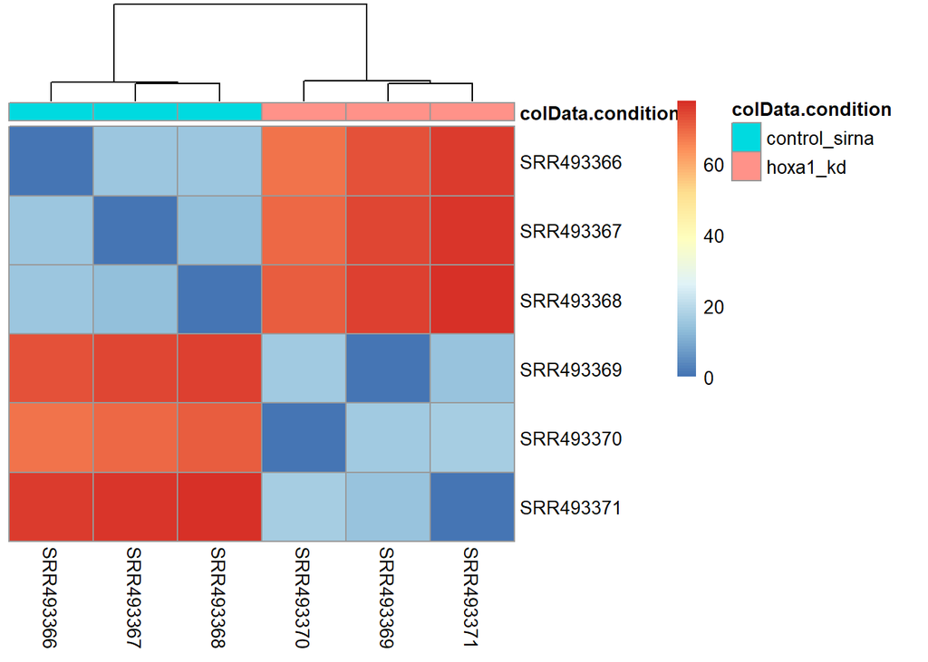

```r
sampleDists = dist(t(assay(rld)),upper = TRUE)

annot_col = data.frame(colData$condition)
row.names(annot_col) <- rownames(colData)

sampleDistMatrix = as.matrix( sampleDists )
rownames(sampleDistMatrix) = colnames(countData)
colnames(sampleDistMatrix) = colnames(countData)

pheatmap(sampleDistMatrix,
         clustering_distance_rows = sampleDists,
         clustering_distance_cols = sampleDists,
         cluster_rows=FALSE, show_rownames=TRUE,
         cluster_cols=TRUE,
         annotation_col=annot_col)
```

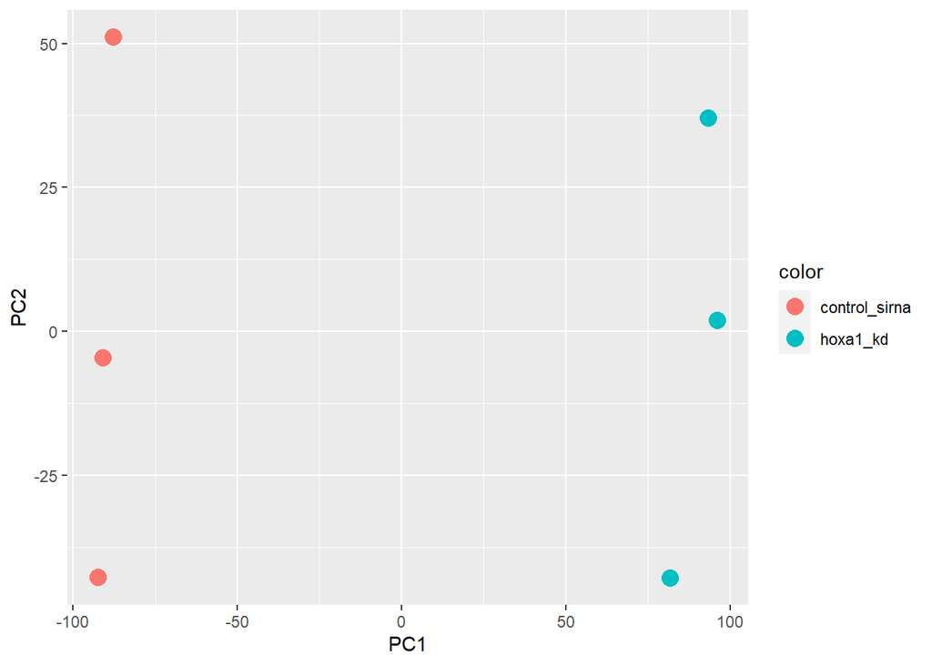

```r
pca_res <- prcomp(t(assay(vsd)), scale. = TRUE)
score <- pca_res$x

score = as.data.frame(score)
score$color <- as.factor(colData$condition)


ggplot(score, aes(x=PC1, y=PC2,  color=color)) +
  geom_point(size = 4)
```

Instead of using all the data, we can filter for significant genes or the top upregulated and downregulated genes. By using the normalized counts and the indices of the significant or top genes, we can plot the PCA and heatmap for a more focused visualization. This approach highlights the key features driving the biological differences in the dataset.

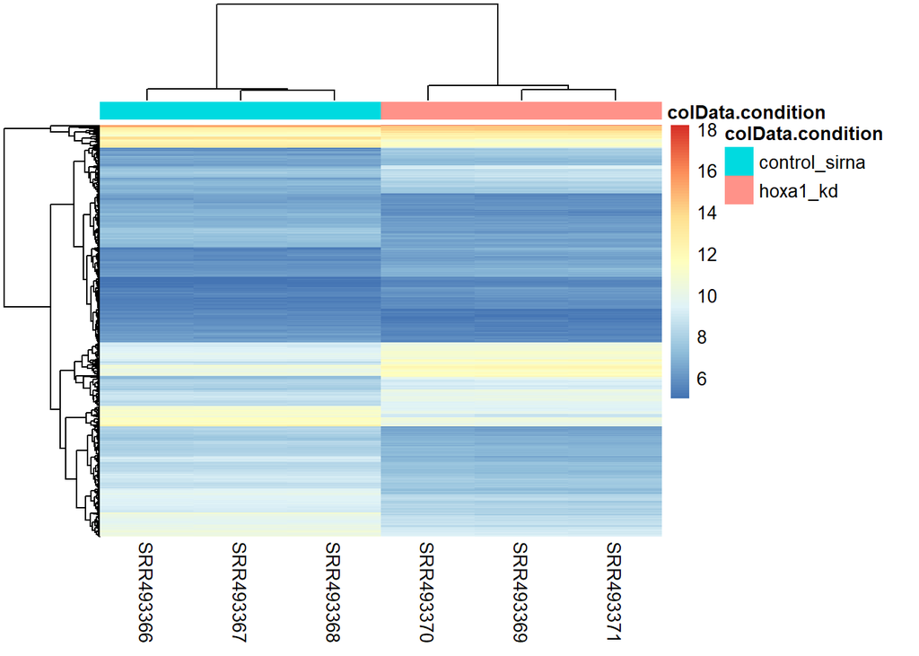

```r
annot_col = data.frame(colData$condition)
row.names(annot_col) <- rownames(colData)

sampleMatrix <- assay(vsd)[genes.significant,]
# sampleMatrix <- assay(vsd)[genes.top,]

rownames(sampleMatrix) = rownames(countData[genes.significant,])
# rownames(sampleMatrix) = rownames(countData[genes.top,])
colnames(sampleMatrix) = colnames(countData)

pheatmap(sampleMatrix ,
         cluster_rows=TRUE,
         show_rownames=FALSE,
         cluster_cols=TRUE,
         annotation_col=annot_col)
```

# 6- Adding gene annotation

Since we mapped and counted against the Ensembl annotation, our results only have information about Ensembl gene IDs. However, our pathway analysis downstream will use KEGG pathways, and genes in KEGG pathways are annotated with Entrez gene IDs.

```r
library("AnnotationDbi")
library("org.Hs.eg.db")
columns(org.Hs.eg.db)
```

```
##  [1] "ACCNUM"       "ALIAS"        "ENSEMBL"      "ENSEMBLPROT"  "ENSEMBLTRANS"
##  [6] "ENTREZID"     "ENZYME"       "EVIDENCE"     "EVIDENCEALL"  "GENENAME"
## [11] "GENETYPE"     "GO"           "GOALL"        "IPI"          "MAP"
## [16] "OMIM"         "ONTOLOGY"     "ONTOLOGYALL"  "PATH"         "PFAM"
## [21] "PMID"         "PROSITE"      "REFSEQ"       "SYMBOL"       "UCSCKG"
## [26] "UNIPROT"
```

```r
res$symbol = mapIds(org.Hs.eg.db,
                    keys=row.names(res),
                    column="SYMBOL",
                    keytype="ENSEMBL",
                    multiVals="first")
res$entrez = mapIds(org.Hs.eg.db,
                    keys=row.names(res),
                    column="ENTREZID",
                    keytype="ENSEMBL",
                    multiVals="first")
res$name =   mapIds(org.Hs.eg.db,
                    keys=row.names(res),
                    column="GENENAME",
                    keytype="ENSEMBL",
                    multiVals="first")
head(res, 10)
```

```
## log2 fold change (MLE): condition hoxa1_kd vs control_sirna
## Wald test p-value: condition hoxa1 kd vs control sirna
## DataFrame with 10 rows and 9 columns
##                  baseMean log2FoldChange     lfcSE       stat      pvalue
##                 <numeric>      <numeric> <numeric>  <numeric>   <numeric>
## ENSG00000279457   29.9136      0.1792571 0.3248216   0.551863 5.81042e-01
## ENSG00000187634  183.2296      0.4264571 0.1402658   3.040350 2.36304e-03
## ENSG00000188976 1651.1881     -0.6927205 0.0548465 -12.630158 1.43990e-36
## ENSG00000187961  209.6379      0.7297556 0.1318599   5.534326 3.12428e-08
## ENSG00000187583   47.2551      0.0405765 0.2718928   0.149237 8.81366e-01
## ENSG00000187642   11.9798      0.5428105 0.5215598   1.040744 2.97994e-01
## ENSG00000188290  108.9221      2.0570638 0.1969053  10.446970 1.51282e-25
## ENSG00000187608  350.7169      0.2573837 0.1027266   2.505522 1.22271e-02
## ENSG00000188157 9128.4394      0.3899088 0.0467163   8.346304 7.04321e-17
## ENSG00000131591  156.4791      0.1965923 0.1456109   1.350121 1.76977e-01
##                        padj      symbol      entrez                   name
##                   <numeric> <character> <character>            <character>
## ENSG00000279457 6.85033e-01          NA          NA                     NA
## ENSG00000187634 5.14039e-03      SAMD11      148398 sterile alpha motif ..
## ENSG00000188976 1.75974e-35       NOC2L       26155 NOC2 like nucleolar ..
## ENSG00000187961 1.13044e-07      KLHL17      339451 kelch like family me..
## ENSG00000187583 9.19159e-01     PLEKHN1       84069 pleckstrin homology ..
## ENSG00000187642 4.02066e-01       PERM1       84808 PPARGC1 and ESRR ind..
## ENSG00000188290 1.30113e-24        HES4       57801 hes family bHLH tran..
## ENSG00000187608 2.36679e-02       ISG15        9636 ISG15 ubiquitin like..
## ENSG00000188157 4.20589e-16        AGRN      375790                  agrin
## ENSG00000131591 2.60893e-01    C1orf159       54991 chromosome 1 open re..
```

Great, this is looking good so far. Now lets see how pathway analysis can help us make further sense out of this ranked list of differentially expressed genes.

# 7-Pathway Analysis

Here we are going to use the [**gage**](https://bioconductor.org/packages/release/bioc/html/gage.html) package for pathway analysis. Once we have a list of enriched pathways, we’re going to use the [**pathview**](http://bioconductor.org/packages/release/bioc/html/pathview.html) package to draw pathway diagrams, shading the molecules in the pathway by their degree of up/down-regulation.

## KEGG pathways

The **gageData** package has pre-compiled databases mapping genes to KEGG pathways and GO terms for common organisms. `kegg.sets.hs` is a named list of 229 elements. Each element is a character vector of member gene Entrez IDs for a single KEGG pathway. (See also `go.sets.hs`). The `sigmet.idx.hs` is an index of numbers of signaling and metabolic pathways in `kegg.set.gs`. In other words, KEGG pathway include other types of pathway definitions, like “Global Map” and “Human Diseases”, which may be undesirable in a particular pathway analysis. Therefore, `kegg.sets.hs[sigmet.idx.hs]` gives you the “cleaner” gene sets of signaling and metabolic pathways only.

> **Side-Note**: While there are many freely available tools to do pathway analysis, and some like gage are truly fantastic, many of them are poorly maintained or rarely updated.

Now we can load the packages and setup the KEGG data-sets we need.

```r
library(pathview)
library(gage)
library(gageData)

data(kegg.sets.hs)
data(sigmet.idx.hs)

# Focus on signaling and metabolic pathways only
kegg.sets.hs = kegg.sets.hs[sigmet.idx.hs]

# Examine the first 3 pathways
head(kegg.sets.hs, 3)
```

```
## $`hsa00232 Caffeine metabolism`
## [1] "10"   "1544" "1548" "1549" "1553" "7498" "9"
##
## $`hsa00983 Drug metabolism - other enzymes`
##  [1] "10"     "1066"   "10720"  "10941"  "151531" "1548"   "1549"   "1551"
##  [9] "1553"   "1576"   "1577"   "1806"   "1807"   "1890"   "221223" "2990"
## [17] "3251"   "3614"   "3615"   "3704"   "51733"  "54490"  "54575"  "54576"
## [25] "54577"  "54578"  "54579"  "54600"  "54657"  "54658"  "54659"  "54963"
## [33] "574537" "64816"  "7083"   "7084"   "7172"   "7363"   "7364"   "7365"
## [41] "7366"   "7367"   "7371"   "7372"   "7378"   "7498"   "79799"  "83549"
## [49] "8824"   "8833"   "9"      "978"
##
## $`hsa00230 Purine metabolism`
##   [1] "100"    "10201"  "10606"  "10621"  "10622"  "10623"  "107"    "10714"
##   [9] "108"    "10846"  "109"    "111"    "11128"  "11164"  "112"    "113"
```

[output cut: 19 more lines]

The main **gage()** function requires a named vector of fold changes, where the names of the values are the Entrez gene IDs.

Note that we used the **mapIDs()** function above to obtain Entrez gene IDs (stored in `res$entrez`) and we have the fold change results from DESeq2 analysis (stored in `res$log2FoldChange`).

```r
foldchanges = res$log2FoldChange
names(foldchanges) = res$entrez
head(foldchanges)
```

```
##        <NA>      148398       26155      339451       84069       84808
##  0.17925708  0.42645712 -0.69272046  0.72975561  0.04057653  0.54281049
```

Now, let’s run the **gage** pathway analysis.

```r
# Get the results
keggres = gage(foldchanges, gsets=kegg.sets.hs)
```

See help on the gage function with `?gage`. Specifically, you might want to try changing the value of `same.dir`. This value determines whether to test for changes in a gene set toward a single direction (all genes up or down regulated) or changes towards both directions simultaneously (i.e. any genes in the pathway dysregulated). Here, we’re using the default `same.dir=TRUE`, which will give us separate lists for pathways that are upregulated versus pathways that are down-regulated.

Now lets look at the object returned from **gage()**.

```r
attributes(keggres)
```

```
## $names
## [1] "greater" "less"    "stats"
```

It is a list with three elements, “greater”, “less” and “stats”.

You can also see this in your *Environmnet* panel/tab window of RStudio or use the R command `str(keggres)`.

Like any list we can use the dollar syntax to access a named element, e.g. `head(keggres$greater)` and `head(keggres$less)`.

Lets look at the first few down (less) pathway results:

```r
# Look at the first few down (less) pathways
head(keggres$less)
```

```
##                                          p.geomean stat.mean        p.val
## hsa04110 Cell cycle                   1.003993e-05 -4.353454 1.003993e-05
## hsa03030 DNA replication              8.909558e-05 -3.968611 8.909558e-05
## hsa03013 RNA transport                1.333710e-03 -3.038782 1.333710e-03
## hsa04114 Oocyte meiosis               1.946905e-03 -2.921710 1.946905e-03
## hsa03440 Homologous recombination     2.941989e-03 -2.868141 2.941989e-03
## hsa00010 Glycolysis / Gluconeogenesis 6.059196e-03 -2.558327 6.059196e-03
##                                             q.val set.size         exp1
## hsa04110 Cell cycle                   0.001606390      120 1.003993e-05
## hsa03030 DNA replication              0.007127646       36 8.909558e-05
## hsa03013 RNA transport                0.071131179      143 1.333710e-03
## hsa04114 Oocyte meiosis               0.077876201       99 1.946905e-03
## hsa03440 Homologous recombination     0.094143663       28 2.941989e-03
## hsa00010 Glycolysis / Gluconeogenesis 0.161578551       48 6.059196e-03
```

Each `keggres$less` and `keggres$greater` object is data matrix with gene sets as rows sorted by p-value.

The top “less/down” pathways is “Cell cycle” with the KEGG pathway identifier `hsa04110`.

Now, let’s try out the **pathview()** function from the [pathview package](https://bioconductor.org/packages/release/bioc/html/pathview.html) to make a pathway plot with our RNA-Seq expression results shown in color. To begin with lets manually supply a `pathway.id` (namely the first part of the `"hsa04110 Cell cycle"`) that we could see from the print out above.

```r
pathview(gene.data=foldchanges, pathway.id="hsa04110")
```

```
## Info: Working in directory C:/Personal/BMEG310 2023/BMEG310_2022/Diff expression
```

```
## Info: Writing image file hsa04110.pathview.png
```

This downloads the pathway figure data from KEGG and adds our results to it.

Now, let’s process our results a bit more to automagicaly pull out the top 5 upregulated pathways, then further process that just to get the pathway IDs needed by the **pathview()** function. We’ll use these KEGG pathway IDs for pathview plotting below.

```r
## Focus on top 5 upregulated pathways here for demo purposes only
keggrespathways <- rownames(keggres$greater)[1:5]

# Extract the 8 character long IDs part of each string
keggresids = substr(keggrespathways, start=1, stop=8)
keggresids
```

```
## [1] "hsa04640" "hsa04630" "hsa04142" "hsa00140" "hsa04740"
```

inally, lets pass these IDs in `keggresids` to the **pathview()** function to draw plots for all the top 5 pathways.

```r
# pathview(gene.data=foldchanges, pathway.id=keggresids, species="hsa")
```

# Self-test

1. If we assume p-value of 3%, what would be the expected false positive?
2. If you substract ONE percent from % false positive calculated from (1), how many genes are there?
3. Having results from 1 & 2, list the top 5 upregulated and top 5 downregulated **genes**?
4. Same as to heatmep covered in this tutorial, plot heatmap of the found genes in part (3)

   > Hint 1: In order to test for differential expression, we operate on raw counts. However for other downstream analyses – e.g. for visualization or clustering – it might be useful to work with transformed versions of the count data. Maybe the most obvious choice of transformation is the logarithm. Two alternative approaches that offer more theoretical justification: One makes use of the concept of variance stabilizing transformations (VST) (Tibshirani 1988; Huber et al. 2003; Anders and Huber 2010), and the other is the regularized logarithm or rlog, which incorporates a prior on the sample differences (Love, Huber, and Anders 2014). Both transformations produce transformed data on the log2 scale which has been normalized with respect to library size or other normalization factors.

   > ```r
   > vsd <- vst(dds, blind=FALSE)
   > rld <- rlog(dds, blind=FALSE)
   > head(assay(vsd),5)
   > ```

   > Hint 2: Gene names should be annotated names. The Heatmap should have `annotation_col`. Rows should be the names of genes and columns should be sample names
5. Print the names of 1 most upregulated and 1 most downregulated pathways?

## FAQ:

1. Hi, I’m just having trouble interpreting this results table:

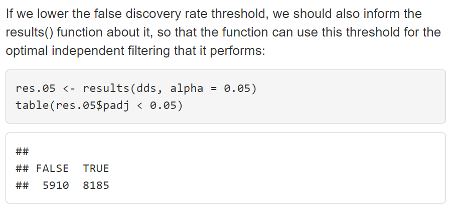

   Why does summing these values also not give us the total number of genes (14095 instead of 15280)? Also why does the TRUE value here differ from the result generated by sum(res$pvalue < 0.05, na.rm=TRUE)?

   **Answer**: Let’s run the following code

   ```
   res.05 <- results(dds, alpha = 0.05)
   table(res.05$padj < 0.05)
   summary(res.05)
   ```

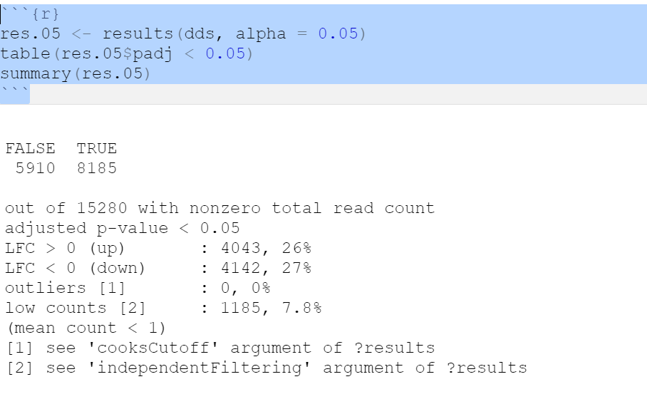

   1- 15280 is the number of all genes with nonzero total read count

   2- The TRUE value which is 8185 equals the sum of LFC > 0 (up) and LFC < 0 (down) : =4043+ 4142 = 8185

   3- if you sum the percentage of data (LFC > 0 (up) and LFC < 0 (down) ) is 26%+ 27% =53% plus 7.8% which is low counts

   4- the remaining is 39.2%. this remaining percent is the percentage FALSE value (5910 genes)

   SO, FALSE(5910) + TRUE(8185) + low counts(1185) = 15280
2. What does low counts means in this case?

**Answer**: let’s type

`metadata(res)$filterThreshold` like

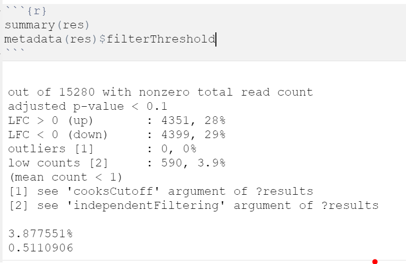

these numbers mean is that DESeq2 has filtered out genes with a mean count of 0.5110906

3. Does the heatmap need to include the same annotation column as the example heatmap in the tutorial? Like the distinction between “control.sirna” and “hoxa1_kd”?

   **Answer**: Yes